**SYS 6018 | Fall 2020 | University of Virginia**

## Crime Linkage

Crime linkage attempts to determine if two or more unsolved crimes share a common offender. *Pairwise* crime linkage is the more simple task of deciding if two crimes share a common offender; it can be considered a binary classification problem. The linkage training data has 8 evidence variables that measure the similarity between a pair of crimes:

- `spatial` is the spatial distance between the crimes
- `temporal` is the fractional time (in days) between the crimes
- `tod` and `dow` are the differences in time of day and day of week between the crimes
- `LOC`, `POA,` and `MOA` are binary with a 1 corresponding to a match (type of property, point of entry, method of entry)
- `TIMERANGE` is the time between the earliest and latest possible times the crime could have occurred (because the victim was away from the house during the crime).
- The response variable indicates if the crimes are linked ($y=1$) or unlinked ($y=0$).

These problems use the [linkage-train](https://mdporter.github.io/SYS6018/data/linkage_train.csv) and [linkage-test](https://mdporter.github.io/SYS6018/data/linkage_test.csv) datasets (click on links for data).

### Problem 4.1: Penalized Regression for Crime Linkage

1. Fit a penalized *linear regression* model. Use a lasso, ridge, or elasticnet penalty (your choice).
   - Report the value of $\alpha$ used (if elasticnet)
   - Report the value of $\lambda$ used
   - Report the estimated coefficients

```r
train = read.csv(file = 'linkage_train.csv')
test = read.csv(file = 'linkage_test.csv')

X.train = as.matrix(train[,-9])
Y.train = as.matrix(train$y)
```

```r
set.seed(123456789)
fold = sample(rep(1:10, length=nrow(X.train)))
Linear = cv.glmnet(X.train, Y.train, alpha=0.8, foldid=fold)
Linear$lambda.min
```

```
#> [1] 0.0001095267
```

```r
#broom::tidy(Linear)
coef(Linear, s="lambda.min")
```

```
#> 9 x 1 sparse Matrix of class "dgCMatrix"
#>                         1
#> (Intercept)  0.0934641223
#> spatial     -0.0023501180
#> temporal    -0.0001566842
#> tod         -0.0022187514
#> dow         -0.0058016466
#> LOC          0.0431174802
#> POA          0.0092812350
#> MOA          0.0071740811
#> TIMERANGE    0.0000249481
```

2. Fit a penalized *logistic regression* model. Use a lasso, ridge, or elasticnet penalty (your choice).
   - Report the value of $\alpha$ used (if elasticnet)
   - Report the value of $\lambda$ used
   - Report the estimated coefficients

```r
set.seed(123456789)
fit.enet = cv.glmnet(y~., data=train,
                     alpha=.5,
                     family="binomial")

broom::tidy(fit.enet)
```

```
#> # A tibble: 72 x 6
#>    lambda estimate std.error conf.low conf.high nzero
#>     <dbl>    <dbl>     <dbl>    <dbl>     <dbl> <int>
#>  1 0.0465    0.170   0.00569    0.164     0.175     0
#>  2 0.0424    0.167   0.00569    0.162     0.173     1
#>  3 0.0386    0.165   0.00559    0.159     0.170     1
#>  4 0.0352    0.162   0.00551    0.156     0.167     2
#>  5 0.0321    0.157   0.00540    0.152     0.163     3
#>  6 0.0292    0.152   0.00520    0.147     0.157     3
#>  7 0.0266    0.147   0.00497    0.142     0.152     3
#>  8 0.0243    0.143   0.00477    0.138     0.148     3
#>  9 0.0221    0.139   0.00458    0.134     0.143     3
#> 10 0.0201    0.135   0.00442    0.131     0.140     3
#> # … with 62 more rows
```

```r
fit.enet$lambda.min
```

```
#> [1] 6.911937e-05
```

```r
coef(fit.enet, s="lambda.min")
```

```
#> 9 x 1 sparse Matrix of class "dgCMatrix"
#>                         1
#> (Intercept) -0.0381616590
#> spatial     -0.2842360527
#> temporal    -0.0124142473
#> tod         -0.1131565292
#> dow         -0.2400986498
#> LOC          1.3889222182
#> POA          0.4417718729
#> MOA          0.2121066850
#> TIMERANGE    0.0006149561
```

alpha = 0.5 lambda = 0.00006911937e

3. Produce one plot that has the ROC curves, using the *training data*, for both models (from part a and b). Use color and/or linetype to distinguish between models and include a legend.

```r
set.seed(123456789)

## Using yardstick package

#---------------------------------------------------------------------------#
#-- Performance Metrics and Curves
#---------------------------------------------------------------------------#
#-- train/test split

#-- fit model on training data

#-- Get predictions (of p(x) and gamma(x)) on test data
p.hat = predict(Linear,newx = X.train, newdata=train, type='response')
gamma = predict(Linear,newx = X.train,newdata=train, type='link')

#-- Make Hard classification (use .20 as cut-off)
G.hat = ifelse(p.hat >= .20, 1, 0)

#-- Make Confusion Table
G.test = train$y  # true values
table(predicted=G.hat, truth = G.test) %>% addmargins()
```

```
#>          truth
#> predicted     0     1   Sum
#>       0   29499   501 30000
#>       Sum 29499   501 30000
```

```r
#-- Get performance data (by threshold)
#   This table has one row for every threshold. The columns are the elements
#   of the confusion table plus FPR, TPR
perf = tibble(truth = G.test, gamma, p.hat) %>%
  #- group_by() + summarize() in case of ties
  group_by(gamma, p.hat) %>%
  summarize(n=n(), n.1=sum(truth), n.0=n-sum(truth)) %>% ungroup() %>%
  #- calculate metrics
  arrange(gamma) %>%
  mutate(FN = cumsum(n.1),    # false negatives
         TN = cumsum(n.0),    # true negatives
         TP = sum(n.1) - FN,  # true positives
         FP = sum(n.0) - TN,  # false positives
         N = cumsum(n),       # number of cases predicted to be 1
         TPR = TP/sum(n.1), FPR = FP/sum(n.0)) %>%
  #- only keep relevant metrics
  select(-n, -n.1, -n.0, gamma, p.hat)

perf$ROC <- 'linear_model'

#-- fit model on training data
#-- Get predictions (of p(x) and gamma(x)) on test data
p.hat = predict(fit.enet, newdata=train, type='response')
gamma = predict(fit.enet, newdata=train, type='link')

#-- Make Hard classification (use .10 as cut-off)
G.hat = ifelse(p.hat >= .10, 1, 0)

#-- Make Confusion Table
G.test = train$y  # true values
table(predicted=G.hat, truth = G.test) %>% addmargins()
```

```
#>          truth
#> predicted     0     1   Sum
#>       0   28812   168 28980
#>       1     687   333  1020
#>       Sum 29499   501 30000
```

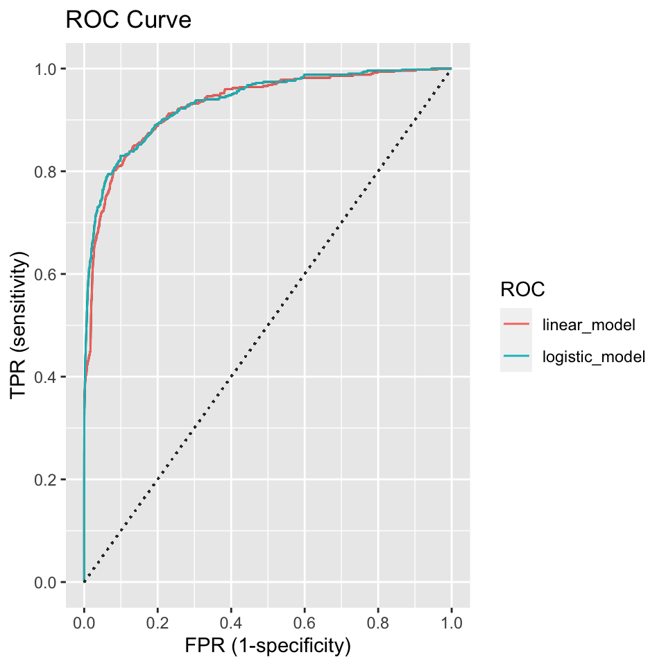

```r
#-- Get performance data (by threshold)
#   This table has one row for every threshold. The columns are the elements
#   of the confusion table plus FPR, TPR
perf_1 = tibble(truth = G.test, gamma, p.hat) %>%
  #- group_by() + summarize() in case of ties
  group_by(gamma, p.hat) %>%
  summarize(n=n(), n.1=sum(truth), n.0=n-sum(truth)) %>% ungroup() %>%
  #- calculate metrics
  arrange(gamma) %>%
  mutate(FN = cumsum(n.1),    # false negatives
         TN = cumsum(n.0),    # true negatives
         TP = sum(n.1) - FN,  # true positives
         FP = sum(n.0) - TN,  # false positives
         N = cumsum(n),       # number of cases predicted to be 1
         TPR = TP/sum(n.1), FPR = FP/sum(n.0)) %>%
  #- only keep relevant metrics
  select(-n, -n.1, -n.0, gamma, p.hat)

perf_1$ROC <- 'logistic_model'

ROC_1 <-  rbind(perf,perf_1)

ROC_1 %>%
  ggplot(aes(FPR, TPR,group = ROC)) + geom_path() + geom_line(alpha = 1, aes(color = ROC, group = ROC)) +
  labs(x='FPR (1-specificity)', y='TPR (sensitivity)') +
  geom_segment(x=0, xend=1, y=0, yend=1, lty=3, color='grey20') +
  scale_x_continuous(breaks = seq(0, 1, by=.20)) +
  scale_y_continuous(breaks = seq(0, 1, by=.20)) +
  ggtitle("ROC Curve")
```

4. Recreate the ROC curve from the penalized logistic regression model using repeated . The following steps will guide you:
   - Fix $\alpha=.75$
   - Run the following steps 25 times:
   1. Hold out 500 observations
   2. Use the remaining observations to estimate $\lambda$
   3. Predict the probability of the 500 hold-out observations
   4. Store the predictions and hold-out labels
   - Combine the results and produce the hold-out based ROC curve
   - Note: by estimating $\lambda$ each iteration, we are incorporating the uncertainty present in estimating that tuning parameter.

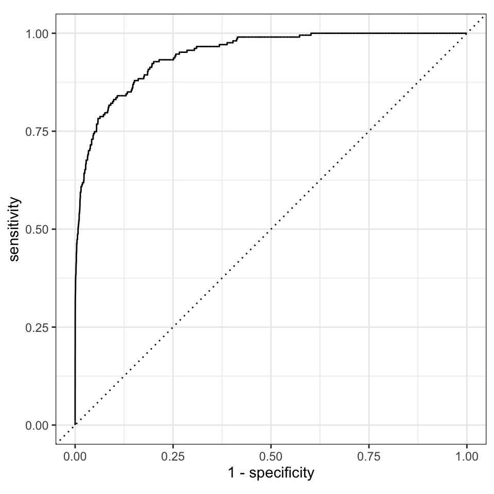

```r
set.seed(123456789)
#create 2 new df to store the predictions and hold-out labels
probability <- data.frame(probability=numeric(0),
                          holdout=numeric(0))

Gamma <-  data.frame(ytest=numeric(0), gamma=numeric(0))

for(i in 1:25) {  # 25 simulation
sample_500 <-  sample(nrow(train), 500)

X.train = train[-sample_500,] %>%
  select(-y) %>%
  as.matrix()
Y.train = train[-sample_500,] %>%
  select(y) %>%
  as.matrix()

fit.log = cv.glmnet(X.train, Y.train, #penalized logistic regression model
                    alpha=.75,
                    family="binomial")

X.test = train[sample_500,] %>%
  select(-y) %>%
  as.matrix()

# prediction
p.hat = predict(fit.log, sample_500="lambda.min", newx=X.test, type="response")
gamma <- predict(fit.log, sample_500="lambda.min", newx=X.test, type="link")

# change to numeric
gamma = as.numeric(gamma)
# change to dataframe type
df_p <- tibble(p.hat)
# add hold-out
df_p$holdout <- i

Y.test = train[sample_500,] %>%
  select(y) %>%
  as.matrix()

df_gamma <-  tibble(ytest = Y.test, gamma = gamma)
Gamma <- rbind(Gamma, df_gamma )
probability <- rbind(probability, df_p)
}

Gamma$gamma <- as.vector(Gamma$gamma)
Gamma$ytest <- as.factor(Gamma$ytest)
combined_25_500 = yardstick::roc_curve(Gamma, ytest,gamma, event_level = 'second')

autoplot(combined_25_500)
```

5. Contest Part 1: Predict the estimated *probability* of linkage for the test data (using any model).
   - Submit a .csv file (ensure comma separated format) named `lastname_firstname_1.csv` that includes the column named **p** that is your estimated posterior probability. We will use automated evaluation, so the format must be exact.
   - You are free to use any tuning parameters
   - You are free to use any data transformation or feature engineering
   - You will receive credit for a proper submission; the top five scores will receive 2 bonus points.
   - Your probabilities will be evaluated with respect to the mean negative Bernoulli log-likelihood (known as the average *log-loss* metric)
     $$L = - \frac{1}{M} \sum_{i=1}^m [y_i \log \, \hat{p}_i + (1 - y_i) \log \, (1 - \hat{p}_i)]$$
     where $M$ is the number of test observations, $\hat{p}_i$ is the prediction for the $i$th test observation, and $y_i \in \{0,1\}$ are the true test set labels.

```r
set.seed(1234567890)

Probability_e = predict(Linear, newx = X.test, newdata=train, s=0.0003314119, type='response')
Probability_e = as.numeric(Probability_e)

# Hard classification
G.hat = ifelse(Probability_e >= .2, 1, 0)

# add column
df_e <- cbind(X.test, Probability_e)
colnames(df_e )[9] <- 'p'


write.csv(as.data.frame(df_e) , "Chen_keyu_1.csv",row.names=FALSE)
```

6. Contest Part 2: Predict the linkages for the test data (using any model).
   - Submit a .csv file (ensure comma separated format) named `lastname_firstname_2.csv` that includes the column named **link** that takes the value of 1 for linkages and 0 for unlinked pairs. We will use automated evaluation, so the format must be exact.
   - You are free to use any tuning parameters.
   - You are free to use any data transformation or feature engineering.
   - Your labels will be evaluated based on total cost, where cost is equal to `1*FP + 8*FN`. This implies that False Negatives (FN) are 8 times as costly as False Negatives (FP)
   - You will receive credit for a proper submission; the top five scores will receive 2 bonus points. Note: you only will get bonus credit for one of the two contests.

```r
df_f <- cbind(X.test, G.hat)
colnames(df_f)[9] <- 'link'

write.csv(as.data.frame(df_f), "Chen_Keyu_2.csv",row.names=FALSE)
```